# Steph Curry: The Game Changer

Grady Munro, Logan Pampel, and Mateo Useche Rosania

# Introduction

We knew that we wanted to do our final project regarding sports. Eventually, we narrowed it down to basketball, and, more specifically, we will follow Stephen Curry’s career and his effect on the league. By looking at the year in which he got drafted in comparison to the league, as well as his team’s statistics before and after his draft, we can begin to draw conclusions in regards to his impact. Additionally, we will compare his game statistics to other NBA legends and three-point specialists. With this context in mind, we began to ask ourselves a set of research questions to guide our data collection, wrangling, and visualization.

When analyzing Stephen Curry’s impact on the NBA, we have three research questions that we want to answer. The first question is: How does Stephen Curry compare to the two greatest of all time, Michael Jordan and Lebron James? To look at Curry’s impact on the league, we must first look at his individual play to see if he belongs in the same category as the greats. The second question is: How has Stephen Curry impacted the Golden State Warriors since he was drafted? The mark of a great leader and player is that he can elevate the team around him, and in order to prove yourself to the league you must first prove yourself to your team. Our third and final question is: How has Stephen Curry changed the nature of the NBA? Since Curry came into the league, there has been a lot of talk about his impact on the NBA. Most people seem to agree that he has had an extraordinary impact, and we want to see if the data supports this claim.

# Our Data

In terms of data collection, we relied on a website called [Basketball Reference](https://www.basketball-reference.com/) which provides in depth statistics about individual players and all the teams in the league. We focused on Stephen Curry, the Warriors, and the overall league data in order to meet the needs of our three research questions. To actually attain our data, we had to use the selector gadget extension and then use the HTML functions to create tables and datasets that worked. Some parts of the website were not compatible with the extension, which meant that we had to change our initial ideas and adapt to what the extensions were able to get from the website. Fortunately, we had enough data from the individual players and teams that we did not need all the data we originally set out to get. Once we had our data, we worked on cleaning it up because the selector gadget does not always give out the cleanest and easiest data to work with. However, by using the janitor library and its functions, we made the dataset a lot more accessible and ready to use.

# Curry Individual Play

We want to start off with: How does Stephen Curry compare to the two greatest basketball players of all time? We will compare these three players using two statistics, their three-pointers made per season, and their average points per game, per season. When looking at three-pointers, it’s not even close. The graph on the left shows the differences in playstyle between the three players. Michael Jordan did not incorporate three-pointers into his game, and it shows, with his best season for this metric not even reaching 100. Lebron James has a more varied playstyle and has incorporated more three-pointers in recent years. Curry is clearly unmatched when it comes to three-pointers, but how about points in general? The graph on the right shows how the three players compare with average points per game. This is where things even out, and we see just how dominant Jordan was. Jordan by far had the highest average points per game, but he saw a sharp decline towards the end of his career. Lebron has had some ups and downs over his career, but he consistently averages between 25 and 30 points per game. Curry falls lowest on this graph, but he clearly has the sharpest takeoff. Curry skyrocketed from the start of his career to match Lebron. He tracks slightly below, but not by much. Both Curry and Lebron look to be on the rise, and it will be interesting to see how they perform in the future. Overall, Curry is comparable to the two greats in these two measures, however, a more holistic analysis would be needed to truly say whether he truly matches up to them.

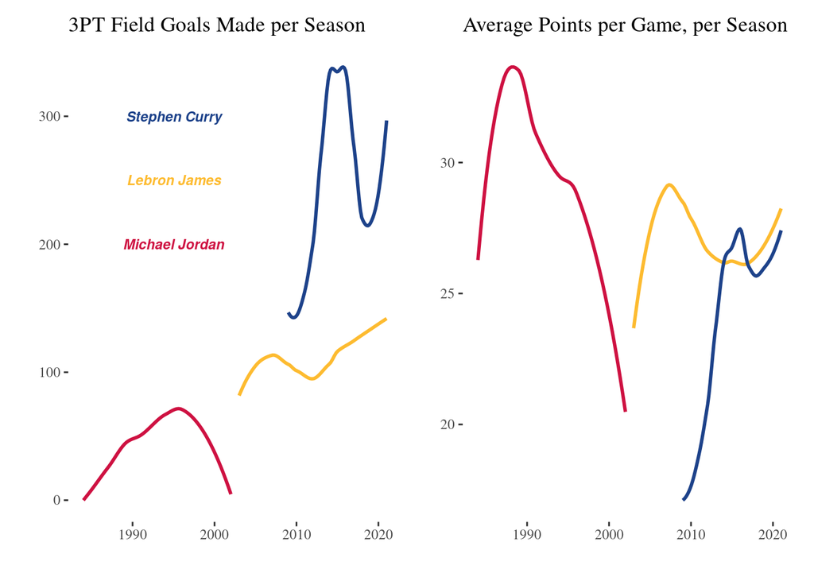

As a short addition to our comparison, we will move into a comparison across three-point shooters over the course of the league. Stephen Curry is clearly the greatest three-point shooter of all time. He holds the record for most career three-pointers, and he also holds the record for most three-pointers in a single season. Looking at the graph below, Ray Allen was a hall of fame player who no one thought could be beaten. However, Curry has smashed that record and has the potential to build such a lead that no one could catch him. Again, Curry is the greatest three-point shooter the league has ever seen, and he will likely be the best for many years to come.

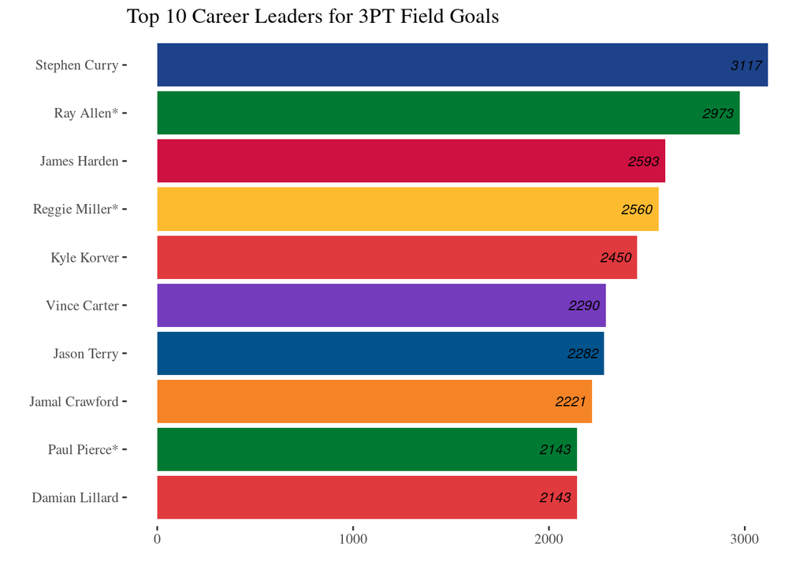

# Warriors

We have seen how Curry matches up with two NBA legends: Lebron James and Michael Jordan. After showing that he matches up, individually, with two of the NBA’s best players, we also wanted to look at what impact Curry has had on the Warriors since he has played for them. Individual accolades are one thing, but making your team better through your style of play is what really makes a player one of the all-time bests. The best way to measure a player’s impact is to measure what basketball is all about: wins. We took all of the Warriors seasons since the three point line had been installed in the NBA and examined how many of the top seasons in the Warriors franchise have been with Curry-led Warrior’s teams. As we can see, Curry has been a part of the top 5 winningest teams of the Warriors and has been a part of 8 of the top 16 winningest teams. This proves that the style of basketball that Curry has ushered into the NBA is a successful winning style.

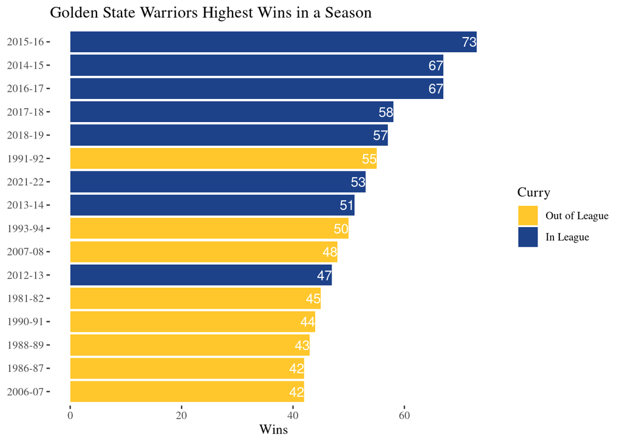

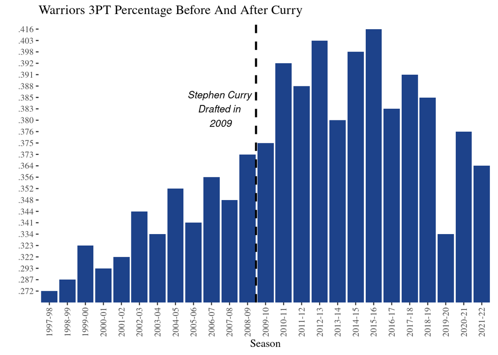

# League (NBA)

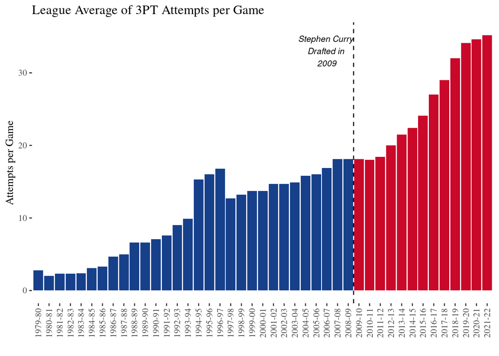

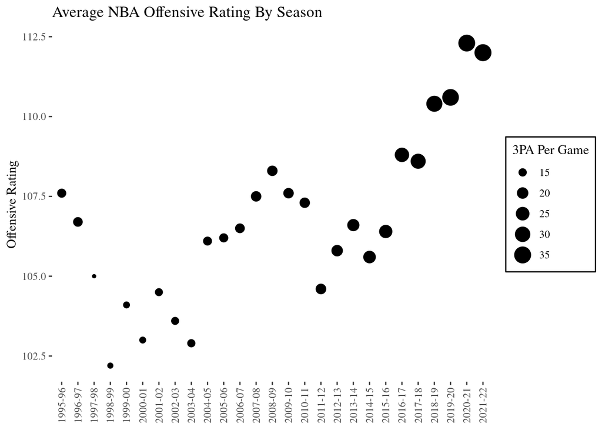

# Conclusion

Our analysis of Curry shows that he truly is a generational player that changed the game of basketball. Curry’s individual scoring statistics in his peak are right on par with the two greatest players of all time. Curry has also made more three-point shots than any other player in NBA history, and he is only 33 years old, meaning he still has more years left in his career. Curry breaking this record at such a young age shows he is like no other player before him in NBA history, and it can be seen since he reached his peak that he has changed the game of basketball league-wide. Since he entered the league, there has been a significant increase in three-point shots attempted per game. According to the average offensive rating across the league, this increase in three-point shots attempted has led to an all-time high in the offensive rating, which shows that this change in the game has led to a more efficient offensive style of basketball. This new style of basketball also leads to team success, as we can see that as Curry entered the league, the Warriors’ increase in three-point efficiency led Curry to be part of some of the winningest Warriors teams in team history. Overall, our analysis of Curry was successful in showing that he is an all-time great player that has had an unmatched impact on his team and the game of basketball as a whole.